# Table of Contents

```python
# モジュールインポート
import pandas as pd
import datetime
import numpy as np
import matplotlib.pyplot as plt
import seaborn as sns
from itertools import product
import warnings
warnings.simplefilter('ignore')
sns.set(font='Yu Gothic')
pd.set_option('display.max_rows', 150)
pd.set_option('display.max_columns', 100)
pd.set_option("display.max_colwidth", 100)

import japanize_matplotlib
import ipynb_path
filename = ipynb_path.get().split("/")[-1].split(".")[0]
cd = ("/".join(ipynb_path.get().split("/")[:-2])).replace("\\","/")
print(filename)
print(cd)
```

```
211019_発表用
C:/Users/r00527522/OneDrive - Ricoh/myenv/kaggle/bento
```

# データインポート

```python
#test
test = pd.read_csv(cd + "/data/test.csv",encoding="shift-jis")
test["test"] = 2

#train
train = pd.read_csv(cd + "/data/train.csv",encoding="shift-jis")
train["test"] = 0

data0 = pd.concat([train,test])
data0["datetime"] = pd.to_datetime(data0["datetime"],errors="coerce")

#年月フラグ作成
data0["ym"] = (data0["datetime"].dt.year-2013)*12+data0["datetime"].dt.month
#weekフラグ作成
data0["monthweek"] = data0["datetime"].dt.day//7
data0["week"] = data0["datetime"].dt.weekday

#降水量欠損処理
data0["precipitation"] = pd.to_numeric(data0["precipitation"],errors="coerce").fillna(-1)

#月別平均売り上げ数（お楽しみメニュー以外）
data0["remarks"] = data0["remarks"].fillna("なし")
tmp = data0[data0["remarks"].str.count("お楽しみ")==0].groupby("ym").agg({"y":"mean"}).reset_index().rename(columns={"y":"y_mean"})
data0 = pd.merge(data0.sort_values("datetime").reset_index(drop=True),tmp,on="ym",how="left")

data0
```

|  | datetime | y | week | soldout | name | kcal | remarks | event | payday | weather | precipitation | temperature | test | ym | monthweek | y_mean |
| --- | --- | --- | --- | --- | --- | --- | --- | --- | --- | --- | --- | --- | --- | --- | --- | --- |
| 0 | 2013-11-18 | 90.0 | 0 | 0 | 厚切りイカフライ | NaN | なし | NaN | NaN | 快晴 | -1.0 | 19.8 | 0 | 11 | 2 | 124.6 |
| 1 | 2013-11-19 | 101.0 | 1 | 1 | 手作りヒレカツ | NaN | なし | NaN | NaN | 快晴 | -1.0 | 17.0 | 0 | 11 | 2 | 124.6 |
| 2 | 2013-11-20 | 118.0 | 2 | 0 | 白身魚唐揚げ野菜あん | NaN | なし | NaN | NaN | 快晴 | -1.0 | 15.5 | 0 | 11 | 2 | 124.6 |
| 3 | 2013-11-21 | 120.0 | 3 | 1 | 若鶏ピリ辛焼 | NaN | なし | NaN | NaN | 快晴 | -1.0 | 15.2 | 0 | 11 | 3 | 124.6 |
| 4 | 2013-11-22 | 130.0 | 4 | 1 | ビッグメンチカツ | NaN | なし | NaN | NaN | 快晴 | -1.0 | 16.1 | 0 | 11 | 3 | 124.6 |
| ... | ... | ... | ... | ... | ... | ... | ... | ... | ... | ... | ... | ... | ... | ... | ... | ... |
| 242 | 2014-11-21 | NaN | 4 | 0 | ロコモコ丼 | NaN | お楽しみメニュー | NaN | NaN | 快晴 | -1.0 | 14.9 | 2 | 23 | 3 | NaN |
| 243 | 2014-11-25 | NaN | 1 | 1 | なすと挽肉のはさみ揚げ | 460.0 | なし | NaN | NaN | 雨 | 1.5 | 11.4 | 2 | 23 | 3 | NaN |
| 244 | 2014-11-26 | NaN | 2 | 1 | 鶏肉の治部煮風 | 415.0 | なし | NaN | NaN | 雨 | 1.0 | 9.2 | 2 | 23 | 3 | NaN |
| 245 | 2014-11-27 | NaN | 3 | 0 | 牛丼風 | 420.0 | なし | NaN | NaN | 快晴 | -1.0 | 15.1 | 2 | 23 | 3 | NaN |
| 246 | 2014-11-28 | NaN | 4 | 0 | 鶏肉のスイートチリソース | 416.0 | なし | NaN | NaN | 曇 | -1.0 | 15.3 | 2 | 23 | 4 | NaN |

247 rows × 16 columns

# 売上推移

## 過去データの使用是非

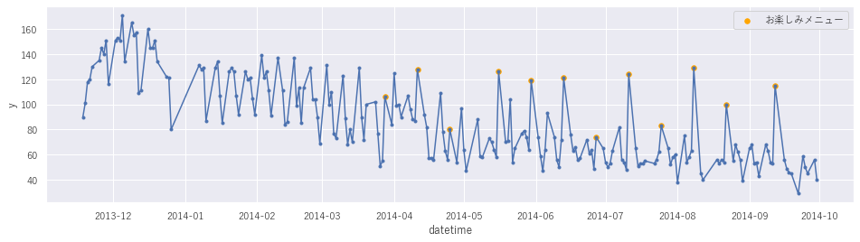

```python
plt.figure(figsize=(16,4))
plt.plot(data0["datetime"],data0["y"],marker="o",markersize=3)
plt.scatter(data0[(data0["remarks"]=="お楽しみメニュー")]["datetime"],
            data0[(data0["remarks"]=="お楽しみメニュー")]["y"],s=30,c="orange",label="お楽しみメニュー")
plt.ylabel("y")
plt.xlabel("datetime")
plt.legend()
plt.show()
```

①お楽しみメニューを除いた通常メニューの売上数は減少傾向にある。  
→過去データよりも売上が小さくなる可能性があるため、決定木系モデル使用時は工夫が必要（例:目的変数を何らかの比率や差分などに変換する）  
②お楽しみメニュー開始前後でデータ変動の傾向が異なっている。  
→直近傾向と異なる2014/4以前は使用すべきではなさそう。

① ２か月前の月別中央値からの差分を目的変数にして予測  
ランダムフォレストで 33 → 12.58 に改善

② 2014/4以前データを除去して予測  
12.58 → 11.05 に改善

目的変数の作り方をもっと工夫すれば更なる向上が期待できそう

## お楽しみメニューの推移

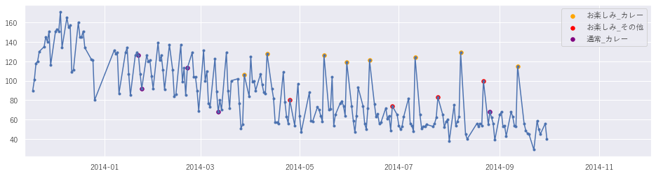

```python
plt.figure(figsize=(16,4))
plt.plot(data0["datetime"],data0["y"],marker="o",markersize=3)
plt.scatter(data0[(data0["remarks"]=="お楽しみメニュー")&(data0["name"].str[-3:]=="カレー")]["datetime"],
            data0[(data0["remarks"]=="お楽しみメニュー")&(data0["name"].str[-3:]=="カレー")]["y"],
            s=30,c="orange",label="お楽しみ_カレー")
plt.scatter(data0[(data0["remarks"]=="お楽しみメニュー")&(data0["name"].str[-3:]!="カレー")]["datetime"],
            data0[(data0["remarks"]=="お楽しみメニュー")&(data0["name"].str[-3:]!="カレー")]["y"],
            s=30,c="red",label="お楽しみ_その他")
plt.scatter(data0[(data0["remarks"]!="お楽しみメニュー")&(data0["name"].str[-3:]=="カレー")]["datetime"],
            data0[(data0["remarks"]!="お楽しみメニュー")&(data0["name"].str[-3:]=="カレー")]["y"],
            s=30,c="purple",label="通常_カレー")

plt.xlim(data0["datetime"].min()-datetime.timedelta(days=5),data0["datetime"].max()+datetime.timedelta(days=5))
plt.legend()
plt.show()
```

お楽しみ＋カレー 常に人気  
お楽しみ＋その他 通常メニューと同水準だったが、最近人気上昇中。今後カレーと並ぶ可能性あり。 通常 ＋カレー 2014/8/26 キーマカレー(お楽しみメニューでも発売実績ありなのに他メニューと同水準)

→あくまで、お楽しみメニューであることが重要なのかも(値段？曜日？)

```python
data0[(data0["name"].str[-3:]=="カレー")]
```

|  | datetime | y | week | soldout | name | kcal | remarks | event | payday | weather | precipitation | temperature | test | ym | monthweek | y_mean |
| --- | --- | --- | --- | --- | --- | --- | --- | --- | --- | --- | --- | --- | --- | --- | --- | --- |
| 38 | 2014-01-22 | 126.0 | 2 | 1 | 手作りひれかつとカレー | 426.0 | なし | NaN | NaN | 快晴 | -1.0 | 7.4 | 0 | 13 | 3 | 115.222222 |
| 40 | 2014-01-24 | 92.0 | 4 | 1 | 鶏のレモンペッパー焼orカレー | 418.0 | 鶏のレモンペッパー焼（50食）、カレー（42食） | NaN | NaN | 快晴 | -1.0 | 10.1 | 0 | 13 | 3 | 115.222222 |
| 59 | 2014-02-21 | 113.0 | 4 | 0 | 酢豚orカレー | 410.0 | 酢豚（28食）、カレー（85食） | ママの会 | NaN | 快晴 | -1.0 | 8.5 | 0 | 14 | 3 | 107.842105 |
| 72 | 2014-03-12 | 68.0 | 2 | 0 | ビーフカレー | 370.0 | なし | NaN | NaN | 快晴 | -1.0 | 14.8 | 0 | 15 | 1 | 88.473684 |
| 83 | 2014-03-28 | 106.0 | 4 | 0 | キーマカレー | NaN | お楽しみメニュー | NaN | NaN | 快晴 | -1.0 | 18.5 | 0 | 15 | 4 | 88.473684 |
| 93 | 2014-04-11 | 128.0 | 4 | 1 | チキンカレー | NaN | お楽しみメニュー | NaN | NaN | 快晴 | -1.0 | 16.5 | 0 | 16 | 1 | 83.842105 |
| 115 | 2014-05-16 | 126.0 | 4 | 0 | ポークカレー | NaN | お楽しみメニュー | ママの会 | NaN | 快晴 | -1.0 | 23.8 | 0 | 17 | 2 | 68.833333 |
| 125 | 2014-05-30 | 119.0 | 4 | 0 | チキンカレー | NaN | お楽しみメニュー | NaN | NaN | 薄曇 | -1.0 | 26.9 | 0 | 17 | 4 | 68.833333 |
| 135 | 2014-06-13 | 121.0 | 4 | 0 | キーマカレー | NaN | お楽しみメニュー | NaN | NaN | 晴れ | -1.0 | 29.5 | 0 | 18 | 1 | 64.105263 |
| 155 | 2014-07-11 | 124.0 | 4 | 0 | ポークカレー | NaN | お楽しみメニュー | NaN | NaN | 晴れ | -1.0 | 33.9 | 0 | 19 | 1 | 57.150000 |
| 174 | 2014-08-08 | 129.0 | 4 | 0 | チキンカレー | NaN | お楽しみメニュー | NaN | 1.0 | 曇 | -1.0 | 31.1 | 0 | 20 | 1 | 54.500000 |
| 183 | 2014-08-26 | 68.0 | 1 | 0 | キーマカレー | 400.0 | なし | NaN | NaN | 雨 | 0.0 | 26.2 | 0 | 20 | 3 | 54.500000 |
| 196 | 2014-09-12 | 115.0 | 4 | 0 | ポークカレー | NaN | お楽しみメニュー | NaN | NaN | 晴れ | -1.0 | 27.3 | 0 | 21 | 1 | 52.421053 |
| 212 | 2014-10-08 | NaN | 2 | 0 | 完熟トマトのホットカレー | 420.0 | なし | NaN | NaN | 晴れ | -1.0 | 23.3 | 2 | 22 | 1 | NaN |
| 214 | 2014-10-10 | NaN | 4 | 0 | ポークカレー | NaN | お楽しみメニュー | NaN | 1.0 | 薄曇 | -1.0 | 26.1 | 2 | 22 | 1 | NaN |
| 232 | 2014-11-07 | NaN | 4 | 0 | ポークカレー | NaN | お楽しみメニュー | NaN | NaN | 晴れ | -1.0 | 20.1 | 2 | 23 | 1 | NaN |

```python
#いらない範囲を除去
data1 = data0[data0["ym"]>=17]
```

# 天気と販売数の相関

## weather

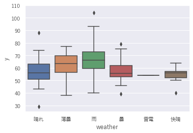

```
曇     26
晴れ    25
薄曇    18
雨     15
快晴     7
雷電     1
Name: weather, dtype: int64
```

```python
sns.boxplot(data=data1[(data1["test"]==0)&(data1["remarks"]!="お楽しみメニュー")],x="weather",y="y")
plt.ylim(25,110)
plt.show()
data1[(data1["test"]==0)&(data1["remarks"]!="お楽しみメニュー")]["weather"].value_counts()
```

雨の時が最も中央値が大きい → 雨天だと弁当で済まそうとする人が多い傾向？

## precipitation

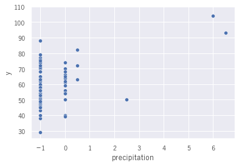

[output not shown]

```python
tmp = data1[(data1["test"]==0)&(data1["remarks"]!="お楽しみメニュー")]
sns.scatterplot(data=tmp,x="precipitation",y="y")
plt.ylim(25,110)
plt.show()
data1[(data1["test"]==0)&(data1["remarks"]!="お楽しみメニュー")&(data1["precipitation"]>2)]
```

大雨(5mm以上)の時は売り上げが多そう  
2.5mmのときは、準備数が50しかなかっただけかも。この場合の予測への影響は？？

同じ降水量の括りでは、天気はあまり影響なし？

## temperature

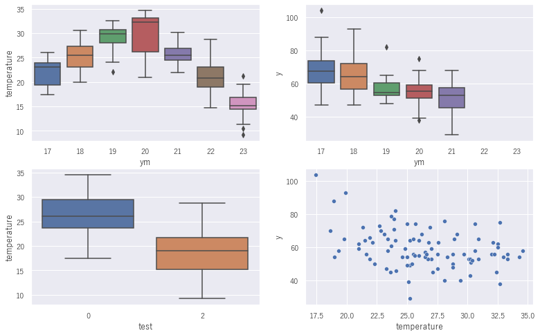

```python
plt.figure(figsize=(13,8))
plt.subplot(2,2,1)
sns.boxplot(data=data1[data1["remarks"]!="お楽しみメニュー"],x="ym",y="temperature")
plt.subplot(2,2,2)
sns.boxplot(data=data1[data1["remarks"]!="お楽しみメニュー"],x="ym",y="y")
plt.subplot(2,2,3)
sns.boxplot(data=data1[data1["remarks"]!="お楽しみメニュー"],x="test",y="temperature")
plt.subplot(2,2,4)
sns.scatterplot(data=data1[data1["remarks"]!="お楽しみメニュー"],x="temperature",y="y")
plt.show()
```

test範囲がtrain範囲より低い領域にあるため、そのままの値は使わないほうがいいかもしれない。

仮説：いつもより暑い/寒いなどで外出を避ける傾向

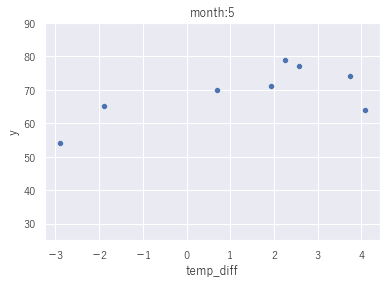

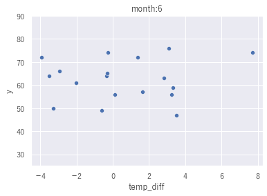

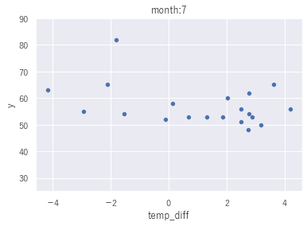

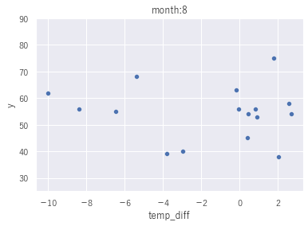

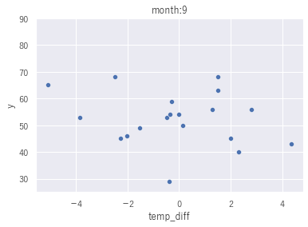

```python
#過去10日間の平均気温との差分
data1["temp_diff"] = data1["temperature"] - data1["temperature"].shift(1).rolling(10).mean()
for i in data1[data1["test"]==0]["ym"].unique():
    tmp = data1[(data1["ym"]==i)&(data1["remarks"]!="お楽しみメニュー")&(data1["precipitation"]<=5)]
    sns.scatterplot(data=tmp,x="temp_diff",y="y")
    plt.ylim(25,90)
    plt.title("month:"+str(i-12))
    plt.show()
```

相関はあまりなさそうだった

# 日付との関係

## 曜日

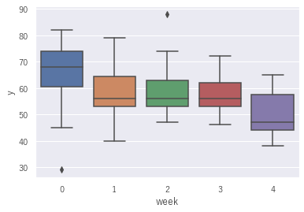

```python
sns.boxplot(data=data1[(data1["test"]==0)&(data1["remarks"]!="お楽しみメニュー")&(data1["precipitation"]<=5)],x="week",y="y")
```

月曜が多く、金曜が少ない傾向

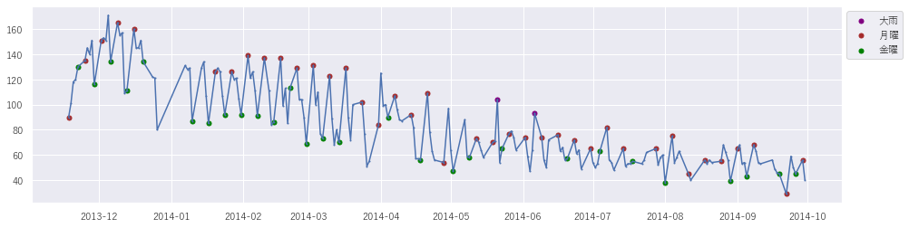

```python
plt.figure(figsize=(16,4))
plt.plot(data0[(data0["remarks"]!="お楽しみメニュー")]["datetime"],
         data0[(data0["remarks"]!="お楽しみメニュー")]["y"],marker="o",markersize=1)

plt.scatter(data0[(data0["precipitation"]>=5)]["datetime"],
            data0[(data0["precipitation"]>=5)]["y"],
            s=25,c="purple",label="大雨")
plt.scatter(data0[(data0["precipitation"]<=5)&(data0["remarks"]!="お楽しみメニュー")&(data0["week"]==0)]["datetime"],
            data0[(data0["precipitation"]<=5)&(data0["remarks"]!="お楽しみメニュー")&(data0["week"]==0)]["y"],
            s=25,c="brown",label="月曜")
plt.scatter(data0[(data0["precipitation"]<=5)&(data0["remarks"]!="お楽しみメニュー")&(data0["week"]==4)]["datetime"],
            data0[(data0["precipitation"]<=5)&(data0["remarks"]!="お楽しみメニュー")&(data0["week"]==4)]["y"],
            s=25,c="green",label="金曜")


plt.legend(bbox_to_anchor=(1., 1), loc='upper left')
plt.show()
```

## 祝日

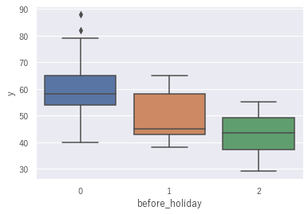

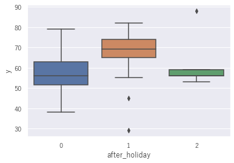

```python
def holiday(d):
    d["before_holiday"] = 0
    d["after_holiday"] = 0
    d.loc[((d["datetime"].shift(-1)-d["datetime"]).dt.total_seconds()/24/60//60)>1,"before_holiday"] = 2
    d.loc[((d["datetime"]-d["datetime"].shift(1)).dt.total_seconds()/24/60//60)>1,"after_holiday"] = 2
    #普通の土日=1
    d.loc[(((d["datetime"].shift(-1)-d["datetime"]).dt.total_seconds()/24/60//60)==3)&(d["week"]==4),"before_holiday"] = 1
    d.loc[(((d["datetime"]-d["datetime"].shift(1)).dt.total_seconds()/24/60//60)==3)&(d["week"]==0),"after_holiday"] = 1
    return d
data0 = holiday(data0)
data1 = holiday(data1)

sns.boxplot(data=data1[(data1["test"]==0)&(data1["remarks"]!="お楽しみメニュー")&(data1["precipitation"]<=5)],x="before_holiday",y="y")
plt.show()
sns.boxplot(data=data1[(data1["test"]==0)&(data1["remarks"]!="お楽しみメニュー")&(data1["precipitation"]<=5)],x="after_holiday",y="y")
plt.show()
```

```python
data1[data1["before_holiday"]==2]
```

|  | datetime | y | week | soldout | name | kcal | remarks | event | payday | weather | precipitation | temperature | test | ym | monthweek | y_mean | before_holiday | after_holiday |
| --- | --- | --- | --- | --- | --- | --- | --- | --- | --- | --- | --- | --- | --- | --- | --- | --- | --- | --- |
| 107 | 2014-05-02 | 47.0 | 4 | 0 | 鶏の天ぷら | 420.0 | なし | NaN | NaN | 晴れ | -1.0 | 23.3 | 0 | 17 | 0 | 68.833333 | 2 | 0 |
| 160 | 2014-07-18 | 55.0 | 4 | 1 | エビフライ | 401.0 | なし | NaN | NaN | 曇 | -1.0 | 25.6 | 0 | 19 | 2 | 57.150000 | 2 | 0 |
| 176 | 2014-08-12 | 40.0 | 1 | 1 | 厚切ハムカツ | 400.0 | なし | NaN | NaN | 雨 | 0.0 | 29.4 | 0 | 20 | 1 | 54.500000 | 2 | 0 |
| 196 | 2014-09-12 | 115.0 | 4 | 0 | ポークカレー | NaN | お楽しみメニュー | NaN | NaN | 晴れ | -1.0 | 27.3 | 0 | 21 | 1 | 52.421053 | 2 | 0 |
| 201 | 2014-09-22 | 29.0 | 0 | 0 | 筑前煮 | 395.0 | なし | NaN | NaN | 晴れ | -1.0 | 25.2 | 0 | 21 | 3 | 52.421053 | 2 | 1 |
| 214 | 2014-10-10 | NaN | 4 | 0 | ポークカレー | NaN | お楽しみメニュー | NaN | 1.0 | 薄曇 | -1.0 | 26.1 | 2 | 22 | 1 | NaN | 2 | 0 |
| 228 | 2014-10-31 | NaN | 4 | 0 | 八宝菜 | 436.0 | なし | NaN | NaN | 曇 | -1.0 | 18.8 | 2 | 22 | 4 | NaN | 2 | 0 |
| 242 | 2014-11-21 | NaN | 4 | 0 | ロコモコ丼 | NaN | お楽しみメニュー | NaN | NaN | 快晴 | -1.0 | 14.9 | 2 | 23 | 3 | NaN | 2 | 0 |

金曜日以外の祝前日は特に少ない → 飛び石連休、夏季休暇前で有休取得奨励日？  
祝日明けはあまり関係なさそう

```python
data1[data1["after_holiday"]==1]
```

|  | datetime | y | week | soldout | name | kcal | remarks | event | payday | weather | precipitation | temperature | test | ym | monthweek | y_mean | before_holiday | after_holiday |
| --- | --- | --- | --- | --- | --- | --- | --- | --- | --- | --- | --- | --- | --- | --- | --- | --- | --- | --- |
| 108 | 2014-05-07 | 88.0 | 2 | 1 | 肉じゃが | 415.0 | なし | NaN | NaN | 晴れ | -1.0 | 18.9 | 0 | 17 | 1 | 68.833333 | 0 | 1 |
| 161 | 2014-07-22 | 53.0 | 1 | 0 | チンジャオロース | 409.0 | なし | NaN | NaN | 晴れ | -1.0 | 30.2 | 0 | 19 | 3 | 57.150000 | 0 | 1 |
| 177 | 2014-08-18 | 56.0 | 0 | 0 | 洋食屋さんのメンチカツ | 396.0 | なし | NaN | NaN | 曇 | -1.0 | 32.2 | 0 | 20 | 2 | 54.500000 | 0 | 1 |
| 197 | 2014-09-16 | 56.0 | 1 | 0 | チーズメンチカツ | 438.0 | なし | NaN | NaN | 晴れ | -1.0 | 28.8 | 0 | 21 | 2 | 52.421053 | 0 | 1 |
| 202 | 2014-09-24 | 59.0 | 2 | 1 | 白身魚のマスタード焼き | 408.0 | なし | NaN | NaN | 曇 | 0.0 | 24.8 | 0 | 21 | 3 | 52.421053 | 0 | 1 |
| 215 | 2014-10-14 | NaN | 1 | 0 | 若鶏梅肉包揚げ | 408.0 | なし | NaN | NaN | 快晴 | -1.0 | 26.8 | 2 | 22 | 2 | NaN | 0 | 1 |
| 229 | 2014-11-04 | NaN | 1 | 0 | 豚肉の生姜焼き | 440.0 | なし | NaN | NaN | 晴れ | -1.0 | 18.9 | 2 | 23 | 0 | NaN | 0 | 1 |
| 243 | 2014-11-25 | NaN | 1 | 1 | なすと挽肉のはさみ揚げ | 460.0 | なし | NaN | NaN | 雨 | 1.5 | 11.4 | 2 | 23 | 3 | NaN | 0 | 1 |

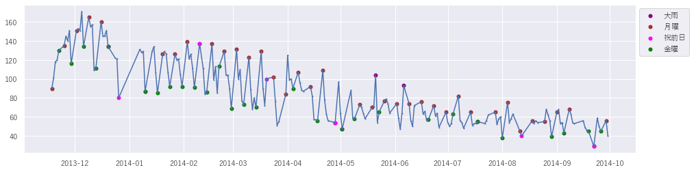

```python
plt.figure(figsize=(16,4))
plt.plot(data0[(data0["remarks"]!="お楽しみメニュー")]["datetime"],
         data0[(data0["remarks"]!="お楽しみメニュー")]["y"],marker="o",markersize=1)

plt.scatter(data0[(data0["precipitation"]>=5)]["datetime"],
            data0[(data0["precipitation"]>=5)]["y"],
            s=25,c="purple",label="大雨")
plt.scatter(data0[(data0["precipitation"]<=5)&(data0["remarks"]!="お楽しみメニュー")&(data0["week"]==0)]["datetime"],
            data0[(data0["precipitation"]<=5)&(data0["remarks"]!="お楽しみメニュー")&(data0["week"]==0)]["y"],
            s=25,c="brown",label="月曜")

plt.scatter(data0[(data0["precipitation"]<=5)&(data0["remarks"]!="お楽しみメニュー")&(data0["before_holiday"]==2)]["datetime"],
            data0[(data0["precipitation"]<=5)&(data0["remarks"]!="お楽しみメニュー")&(data0["before_holiday"]==2)]["y"],
            s=25,c="magenta",label="祝前日")
plt.scatter(data0[(data0["precipitation"]<=5)&(data0["remarks"]!="お楽しみメニュー")&(data0["week"]==4)]["datetime"],
            data0[(data0["precipitation"]<=5)&(data0["remarks"]!="お楽しみメニュー")&(data0["week"]==4)]["y"],
            s=25,c="green",label="金曜")


plt.legend(bbox_to_anchor=(1., 1), loc='upper left')
plt.show()
```

14/5以前は月曜に高くて金曜に低い傾向が顕著 → 曜日によって違いは何かしらありそう  
「毎日一定の売上を確保する」という見方をすると、金曜日にお楽しみメニューを当てるのは理にかなっているのではないか。

# まとめ

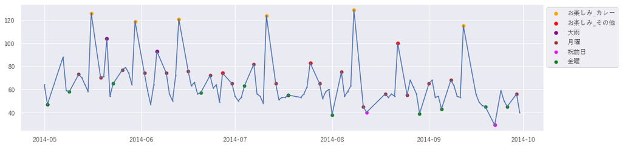

```python
plt.figure(figsize=(16,4))
plt.plot(data1["datetime"],data1["y"],marker="o",markersize=1)
plt.scatter(data1[(data1["remarks"]=="お楽しみメニュー")&(data1["name"].str[-3:]=="カレー")]["datetime"],
            data1[(data1["remarks"]=="お楽しみメニュー")&(data1["name"].str[-3:]=="カレー")]["y"],
            s=30,c="orange",label="お楽しみ_カレー")
plt.scatter(data1[(data1["remarks"]=="お楽しみメニュー")&(data1["name"].str[-3:]!="カレー")]["datetime"],
            data1[(data1["remarks"]=="お楽しみメニュー")&(data1["name"].str[-3:]!="カレー")]["y"],
            s=30,c="red",label="お楽しみ_その他")
plt.scatter(data1[(data1["precipitation"]>=5)]["datetime"],
            data1[(data1["precipitation"]>=5)]["y"],
            s=30,c="purple",label="大雨")

plt.scatter(data1[(data1["precipitation"]<=5)&(data1["remarks"]!="お楽しみメニュー")&(data1["week"]==0)]["datetime"],
            data1[(data1["precipitation"]<=5)&(data1["remarks"]!="お楽しみメニュー")&(data1["week"]==0)]["y"],
            s=25,c="brown",label="月曜")
plt.scatter(data1[(data1["precipitation"]<=5)&(data1["remarks"]!="お楽しみメニュー")&(data1["before_holiday"]==2)]["datetime"],
            data1[(data1["precipitation"]<=5)&(data1["remarks"]!="お楽しみメニュー")&(data1["before_holiday"]==2)]["y"],
            s=25,c="magenta",label="祝前日")
plt.scatter(data1[(data1["precipitation"]<=5)&(data1["remarks"]!="お楽しみメニュー")&(data1["week"]==4)]["datetime"],
            data1[(data1["precipitation"]<=5)&(data1["remarks"]!="お楽しみメニュー")&(data1["week"]==4)]["y"],
            s=25,c="green",label="金曜")
plt.legend(bbox_to_anchor=(1., 1), loc='upper left')
plt.show()
```

お楽しみメニュー（カレー）、大雨、曜日、祝日フラグ である程度変動要因のグルーピングはできそうだということが分かった  
①これらの思考に沿った特徴量を作る  
②減少していく売上をうまく予測できるようなモデル・目的変数の検討  
③他の変動要因を検討する

を実施する。